# Case 4: Encontrando padrões nos dados com clusterização

## Um breve introdução sobre clusterização

> Algoritmos de clusterização são utilizados na criação de modelos de aprendizagem não supervisionado.

> Diferentemente do caso de modelos supervisionados, os algoritmos não supervisionados não requerem um target observável. Isto é, não demandam uma variável resposta `y` para o treinamento do modelo

> Ao invés de buscar padrões em relação a uma resposta, eles identificam padrões nas estruturas dos dados e rotulam as observações de acordo com o agrupamento ao qual ela mais se assemelha

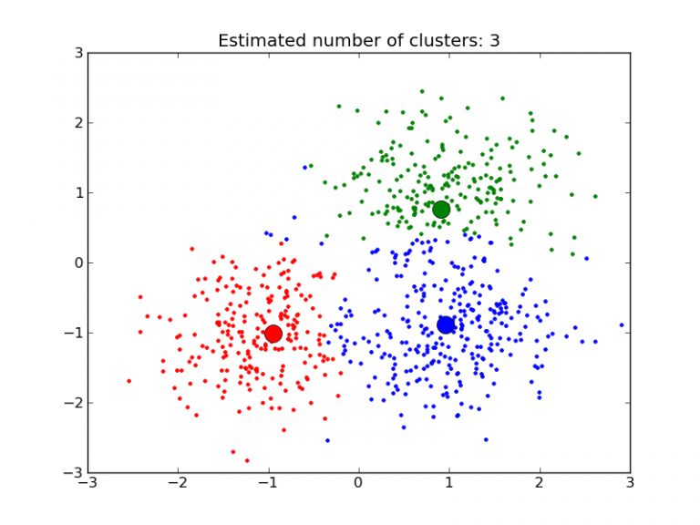

## Libs e dados

```r
# install.packages("factoextra")
```

```r
library(tidyverse)
library(sf)
library(factoextra)
library(cluster)
```

```r
df <- read_sf('../dados/preparados/distritos_cultura.shp')
```

## Preparar dados para clusterizar

Primeiro vamos criar algumas variáveis:

```r
df <- df %>%
  mutate(negros = pretos + pardos,
         equipamentos_pc = (pessoas / eqpmnts) / 10000,
         bibs_pc = (bibltcs / eqpmnts) / 10000,
         teatro_pc = (ttr_cnm / eqpmnts) / 10000,
         museus_pc = (museus / eqpmnts) / 10000,
         ec_pc = (espcs_c / eqpmnts) / 10000,
         pessoas_dom = pessoas / domicls
         )

df$bibs_pc[is.na(df$bibs_pc)] <- 0
df$teatro_pc[is.na(df$teatro_pc)] <- 0
df$museus_pc[is.na(df$museus_pc)] <- 0
df$ec_pc[is.na(df$ec_pc)] <- 0
df$equipamentos_pc[is.infinite(df$equipamentos_pc)] <- 0

df$equip_groups <- factor(ifelse(df$equipamentos_pc > mean(df$equipamentos_pc), 1, 0))
```

No caso da clusterização é aconselhável usar antes duas outras técnicas: a primeira é reescalar os dados e a segunda é aplicar uma Principal Componente Analysis (PCA, ou Análise de Componentes Principais).

### Reescalar os dados

O que faremos é chamado de “padronização Z” ou **Z standardization**:

$$Zscore = \frac{x - \mu}{\sigma}$$

Em outras palavras:

Z-Score = (x - media(x)) / desvio padrao(x)

O que ela faz é centralizar os dados em torno da média, calculando a distância de cada em valor em relação à média em termos de desvio padrão.

Na prática, cada valor se tornará a distância do valor original até a média, em desvios padrões.

No R podemos facilmente reescalar os dados para o Z-Score com a função `scale()`.

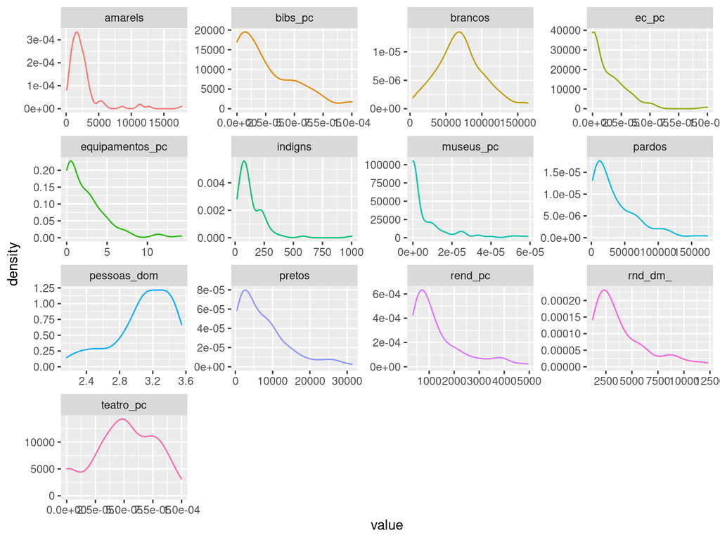

```r
df %>%
  data.frame %>%
  select(brancos, pretos, amarels, pardos, indigns, pessoas_dom, rnd_dm_,
         contains("_pc")) %>%
  pivot_longer(cols=everything()) %>%
  ggplot(aes(x = value, color = name)) +
  geom_density(show.legend = FALSE) +
  facet_wrap(~name, scales = "free")
```

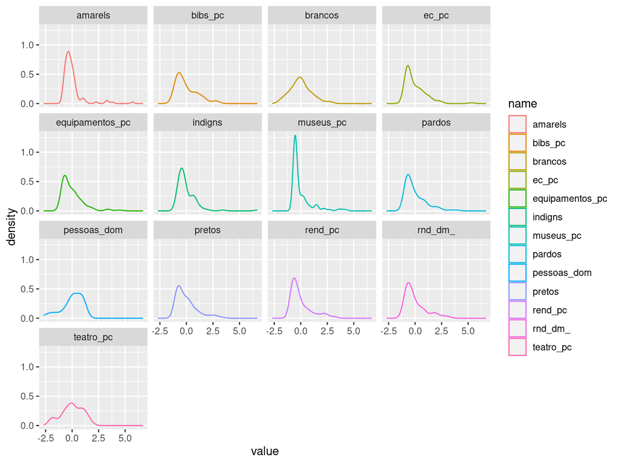

```r
X <- df %>%
  data.frame() %>%
  select(brancos, pretos, amarels, pardos, indigns, pessoas_dom, rnd_dm_,
         contains("_pc")) %>%
  scale() %>%
  data.frame()

rownames(X) <- df$nm_dstr

X %>%
  pivot_longer(cols=everything()) %>%
  ggplot(aes(x = value, color = name)) +
  geom_density() +
  facet_wrap(~name)
```

```r
map_df(df %>% data.frame %>% select(names(X)), ~c(min(.), max(.)), na.rm=TRUE)
```

```
## # A tibble: 2 x 13
##   brancos pretos amarels pardos indigns pessoas_dom rnd_dm_ rend_pc
##     <int>  <int>   <int>  <int>   <int>       <dbl>   <dbl>   <dbl>
## 1    4045    438      92   1811      16        2.16   1218.    350.
## 2  163858  31253   17706 173575    1002        3.55  12255.   4940.
## # … with 5 more variables: equipamentos_pc <dbl>, bibs_pc <dbl>,
## #   teatro_pc <dbl>, museus_pc <dbl>, ec_pc <dbl>
```

```r
map_df(X, ~c(min(.), max(.)), na.rm=TRUE)
```

```
## # A tibble: 2 x 13
##   brancos pretos amarels pardos indigns pessoas_dom rnd_dm_ rend_pc
##     <dbl>  <dbl>   <dbl>  <dbl>   <dbl>       <dbl>   <dbl>   <dbl>
## 1   -2.01  -1.04  -0.928 -0.962  -0.913       -2.65   -1.05  -0.952
## 2    2.79   3.40   5.68   3.91    6.65         1.31    3.16   3.28
## # … with 5 more variables: equipamentos_pc <dbl>, bibs_pc <dbl>,
## #   teatro_pc <dbl>, museus_pc <dbl>, ec_pc <dbl>
```

## Análise de componentes principais

```r
dim(X)
```

```
## [1] 96 13
```

```r
X.pca <- prcomp(X)
summary(X.pca)
```

```
## Importance of components:
##                          PC1    PC2     PC3     PC4     PC5     PC6     PC7
## Standard deviation     2.303 1.3902 1.11348 1.05605 0.99883 0.87463 0.77256
## Proportion of Variance 0.408 0.1487 0.09537 0.08579 0.07674 0.05884 0.04591
## Cumulative Proportion  0.408 0.5566 0.65202 0.73781 0.81455 0.87340 0.91931
##                            PC8     PC9   PC10    PC11    PC12    PC13
## Standard deviation     0.65091 0.48020 0.4475 0.39310 0.18435 0.07707
## Proportion of Variance 0.03259 0.01774 0.0154 0.01189 0.00261 0.00046
## Cumulative Proportion  0.95190 0.96964 0.9850 0.99693 0.99954 1.00000
```

> - The center point ($center), scaling ($scale), standard deviation(sdev) of each principal component
> - The relationship (correlation or anticorrelation, etc) between the initial variables and the principal components ($rotation)
> - The values of each sample in terms of the principal components ($x)

#### Visualização de PCA (biplot)

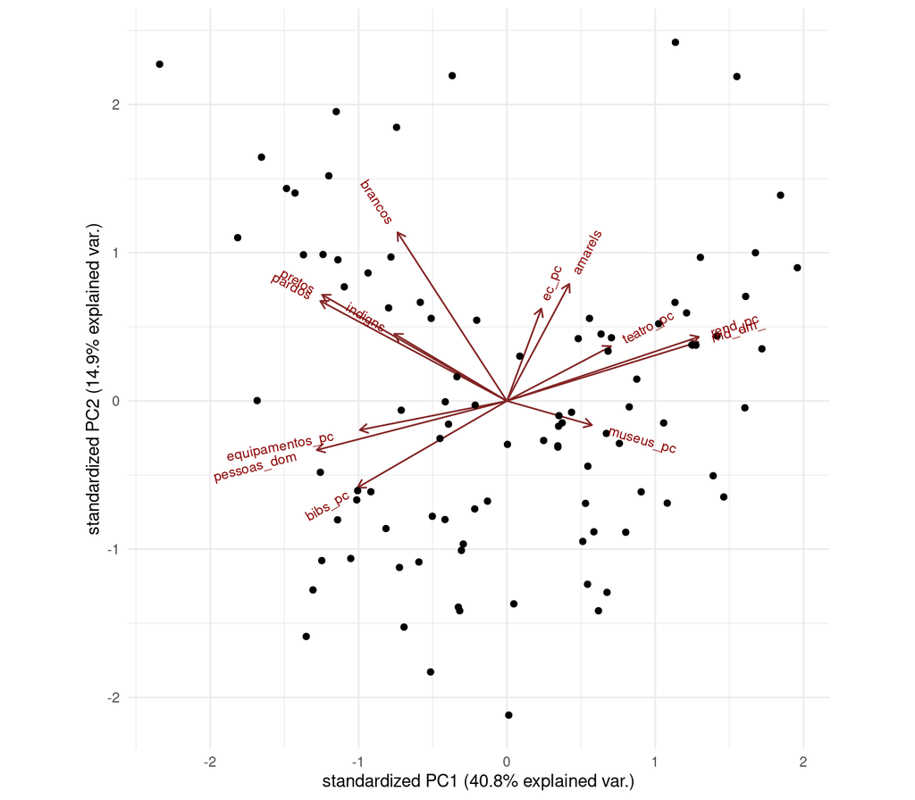

```r
# remotes::install_github("vqv/ggbiplot")
library(ggbiplot)
ggbiplot(X.pca) +
  theme_minimal()
```

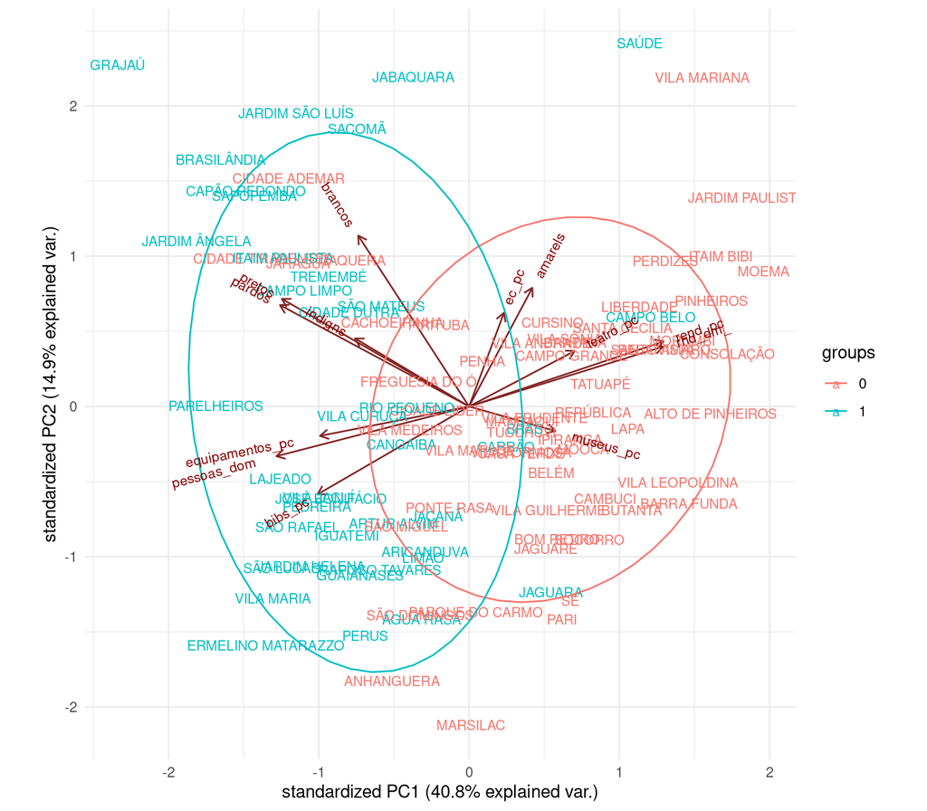

```r
ggbiplot(X.pca, ellipse=TRUE, labels=rownames(X), groups = df$equip_groups) +
  theme_minimal()
```

## Reorganizar a refazer análise de PCA

```r
cols <- c("brancos", "negros_indios", "amarels", "pessoas_dom", "rnd_dm_",
          "bibs_pc", "teatro_pc", "ec_pc", "museus_pc")
df <- df %>%
  mutate(negros_indios = pretos + pardos + indigns)

X <- df %>%
  data.frame %>%
  select(all_of(cols)) %>%
  scale() %>%
  data.frame()
```

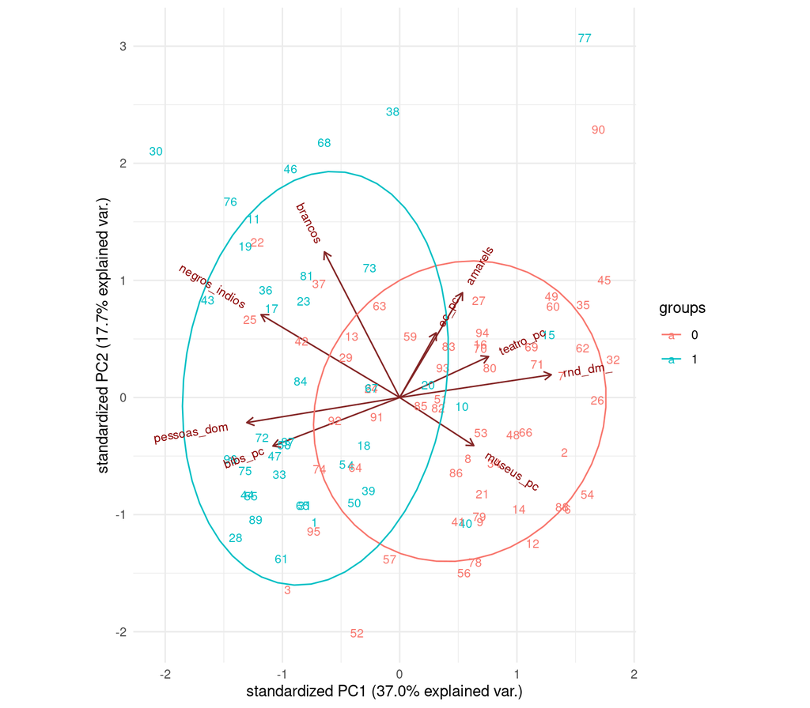

```r
X.pca <- prcomp(X)

ggbiplot(X.pca, ellipse=TRUE, labels=rownames(X), groups = df$equip_groups) +
  theme_minimal()
```

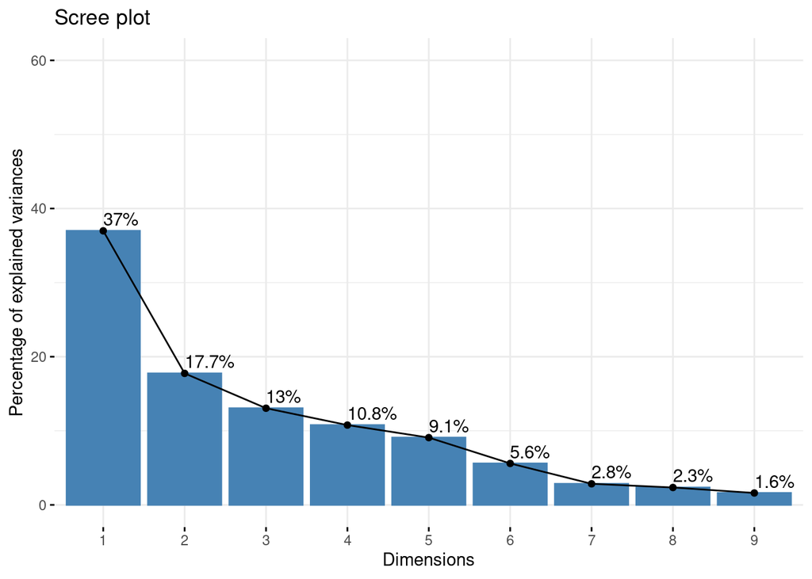

```r
fviz_eig(X.pca, addlabels = TRUE, ylim = c(0, 60))
```

```r
summary(X.pca)
```

```
## Importance of components:
##                           PC1    PC2    PC3    PC4     PC5    PC6    PC7
## Standard deviation     1.8245 1.2638 1.0835 0.9844 0.90384 0.7093 0.5056
## Proportion of Variance 0.3699 0.1775 0.1304 0.1077 0.09077 0.0559 0.0284
## Cumulative Proportion  0.3699 0.5474 0.6778 0.7855 0.87624 0.9321 0.9605
##                            PC8     PC9
## Standard deviation     0.45924 0.37977
## Proportion of Variance 0.02343 0.01602
## Cumulative Proportion  0.98398 1.00000
```

```r
X.proj <- predict(X.pca, X) %>% data.frame
X.proj
```

```
##           PC1         PC2          PC3          PC4          PC5          PC6
## 1  -1.3263365 -1.34928394  0.641091618  0.675228322  2.645454650  1.010654661
## 2   2.5687319 -0.58893281 -0.168966094 -0.759561382  0.352946149  1.190878094
## 3  -1.7418702 -2.07179510 -0.001622652 -0.111298915  1.051817733 -0.097956570
## 4  -0.7565651 -0.73242016 -0.682674183  0.031252916  0.794380064 -0.270971826
## 5  -0.8860213 -0.72230665 -0.631207967 -0.182727967  0.614993938  0.082594205
## 6   2.6105851 -1.20523127 -0.753386601 -1.284450060 -0.143508274  0.289227602
## 7   2.5124977  0.23374074 -0.530068433 -0.631542516  0.270157121  0.173018083
## 8   1.0622711 -0.65924686 -0.675276857 -1.380816320 -0.564476955 -0.810428699
## 9   1.2523403 -1.33832348  0.386495753  1.744308778 -0.888134489 -1.360486809
## 10  0.9676170 -0.09524067  5.011926030 -2.708036769 -0.159031649 -1.778601693
## 11 -2.2689167  1.92740788  0.295697069 -0.424821828 -1.067513476  0.257851440
## 12  2.0693409 -1.57683967  1.773214063  3.153691925 -1.460603989  0.462840261
## 13 -0.7428448  0.66096040  0.896735625 -1.119343232 -0.764088854 -0.689249918
## 14  1.8592662 -1.20243830  1.908965009  0.611800710 -1.216186331 -0.317646709
```

[output cut: 179 more lines]

## Clusterização

### Visualizar distâncias

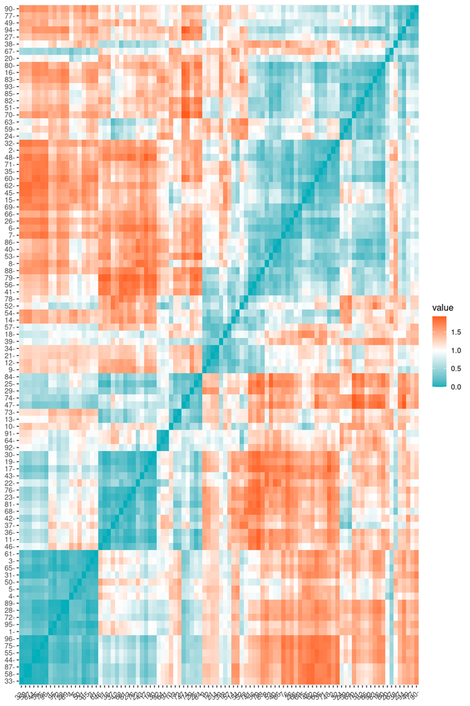

```r
X.dist <- get_dist(X.proj, method = "pearson")

fviz_dist(X.dist,
   gradient = list(low = "#00AFBB", mid = "white", high = "#FC4E07"))
```

### Determinar o número ótimo de clusters

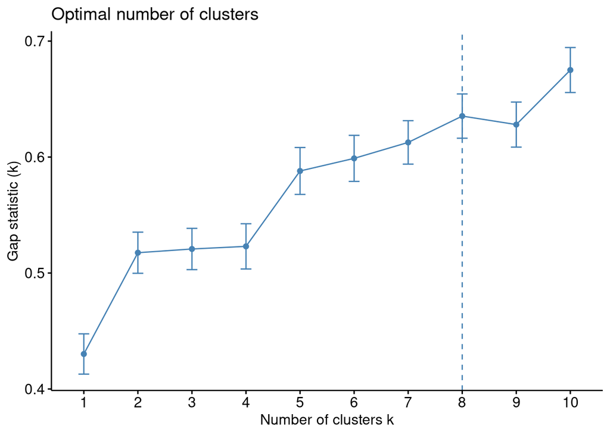

```r
fviz_nbclust(X.proj, kmeans, method = "gap_stat")
```

### Clusterizar com Kmeans

```r
set.seed(123)
X.km <- kmeans(X, 4)
X.km
```

```
## K-means clustering with 4 clusters of sizes 44, 23, 19, 10
##
## Cluster means:
##      brancos negros_indios     amarels pessoas_dom    rnd_dm_    bibs_pc
## 1  0.3299041     0.6896138 -0.37194261   0.7472852 -0.7089384  0.6846913
## 2 -0.6317669    -0.8201677 -0.21254882  -1.1646057  1.0869347 -0.7358067
## 3  0.5077285    -0.2673320  1.15964697  -0.2518414  0.2357272 -0.4035101
## 4 -0.9631982    -0.6399844 -0.07791947  -0.1309628  0.1714974 -0.5536173
##    teatro_pc      ec_pc   museus_pc
## 1 -0.6328525 -0.1052181 -0.45634202
## 2  0.8161207  0.1536010  0.03134344
## 3  0.8515940 -0.3121224 -0.17123241
## 4 -0.7105553  0.7027100  2.26115655
##
## Clustering vector:
##  1  2  3  4  5  6  7  8  9 10 11 12 13 14 15 16 17 18 19 20 21 22 23 24 25 26
##  1  2  1  1  1  2  2  2  4  4  1  4  1  4  2  3  1  1  1  3  4  1  1  3  1  2
## 27 28 29 30 31 32 33 34 35 36 37 38 39 40 41 42 43 44 45 46 47 48 49 50 51 52
##  3  1  1  1  1  2  1  4  2  1  1  3  4  2  2  1  1  1  2  1  1  2  3  1  3  1
## 53 54 55 56 57 58 59 60 61 62 63 64 65 66 67 68 69 70 71 72 73 74 75 76 77 78
##  2  4  1  2  4  1  3  2  1  2  3  1  1  2  3  3  2  3  2  1  1  1  1  1  3  4
## 79 80 81 82 83 84 85 86 87 88 89 90 91 92 93 94 95 96
##  2  2  1  3  3  1  3  2  1  2  1  3  1  1  3  3  1  1
##
## Within cluster sum of squares by cluster:
## [1] 216.66345  88.18597 103.86010  76.08165
##  (between_SS / total_SS =  43.3 %)
##
## Available components:
##
## [1] "cluster"      "centers"      "totss"        "withinss"     "tot.withinss"
## [6] "betweenss"    "size"         "iter"         "ifault"
```

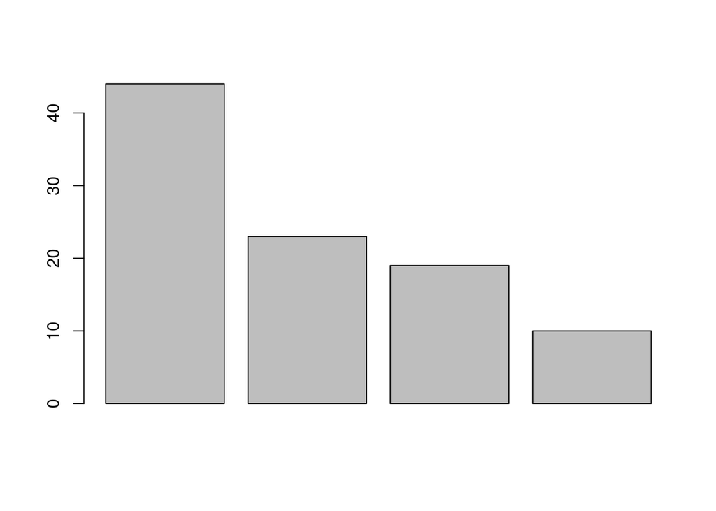

```r
barplot(X.km$size)
```

```r
X.km$size
```

```
## [1] 44 23 19 10
```

### Visualizar clusters

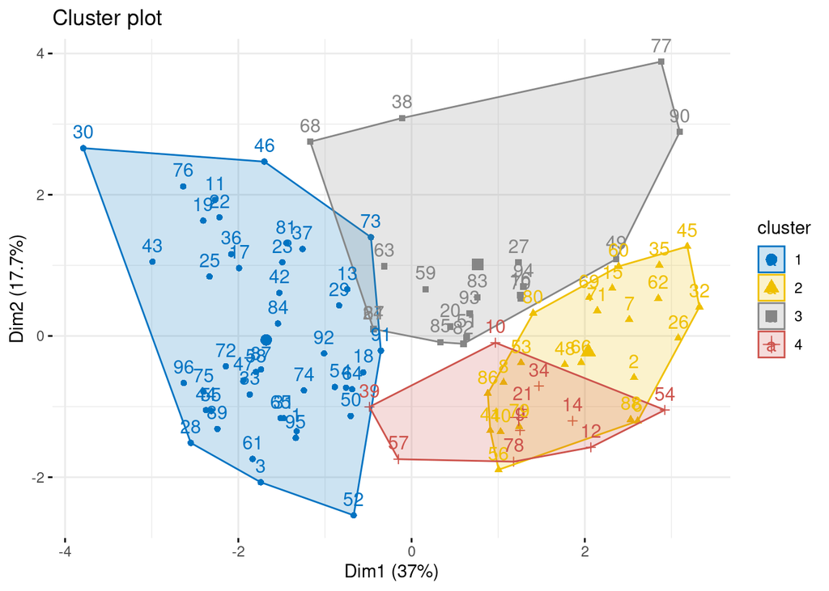

```r
library(factoextra)
fviz_cluster(X.km, data = X,
             ellipse.type = "convex",
             palette = "jco",
             ggtheme = theme_minimal())
```

```r
df$nm_dstr
```

```
##  [1] "ÁGUA RASA"          "ALTO DE PINHEIROS"  "ANHANGUERA"
##  [4] "ARICANDUVA"         "ARTUR ALVIM"        "BARRA FUNDA"
##  [7] "BELA VISTA"         "BELÉM"              "BOM RETIRO"
## [10] "BRÁS"               "BRASILÂNDIA"        "BUTANTÃ"
## [13] "CACHOEIRINHA"       "CAMBUCI"            "CAMPO BELO"
## [16] "CAMPO GRANDE"       "CAMPO LIMPO"        "CANGAIBA"
## [19] "CAPÃO REDONDO"      "CARRÃO"             "CASA VERDE"
## [22] "CIDADE ADEMAR"      "CIDADE DUTRA"       "CIDADE LIDER"
## [25] "CIDADE TIRADENTES"  "CONSOLAÇÃO"         "CURSINO"
## [28] "ERMELINO MATARAZZO" "FREGUESIA DO Ó"     "GRAJAÚ"
## [31] "GUAIANASES"         "MOEMA"              "IGUATEMI"
## [34] "IPIRANGA"           "ITAIM BIBI"         "ITAIM PAULISTA"
## [37] "ITAQUERA"           "JABAQUARA"          "JAÇANÃ"
## [40] "JAGUARA"            "JAGUARÉ"            "JARAGUÁ"
## [43] "JARDIM ÂNGELA"      "JARDIM HELENA"      "JARDIM PAULISTA"
```

[output cut: 17 more lines]

```
## Note: Using an external vector in selections is ambiguous.
## ℹ Use `all_of(cols)` instead of `cols` to silence this message.
## ℹ See <https://tidyselect.r-lib.org/reference/faq-external-vector.html>.
```

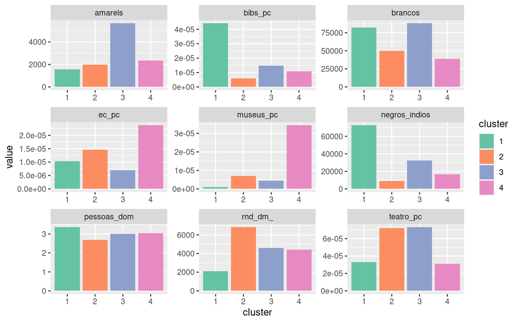

```r
df$cluster <- factor(X.km$cluster)
df %>%
  data.frame %>%
  group_by(cluster) %>%
  mutate(cluster = as.numeric(as.character(cluster))) %>%
  summarise_at(vars(cols), mean) %>%
  pivot_longer(cols=c(-cluster)) %>%
  mutate(cluster = factor(cluster)) %>%
  ggplot(aes(x=cluster, y=value, fill=cluster)) +
  geom_bar(stat="identity") +
  scale_fill_brewer(palette = "Set2") +
  facet_wrap(~name, scales="free")
```

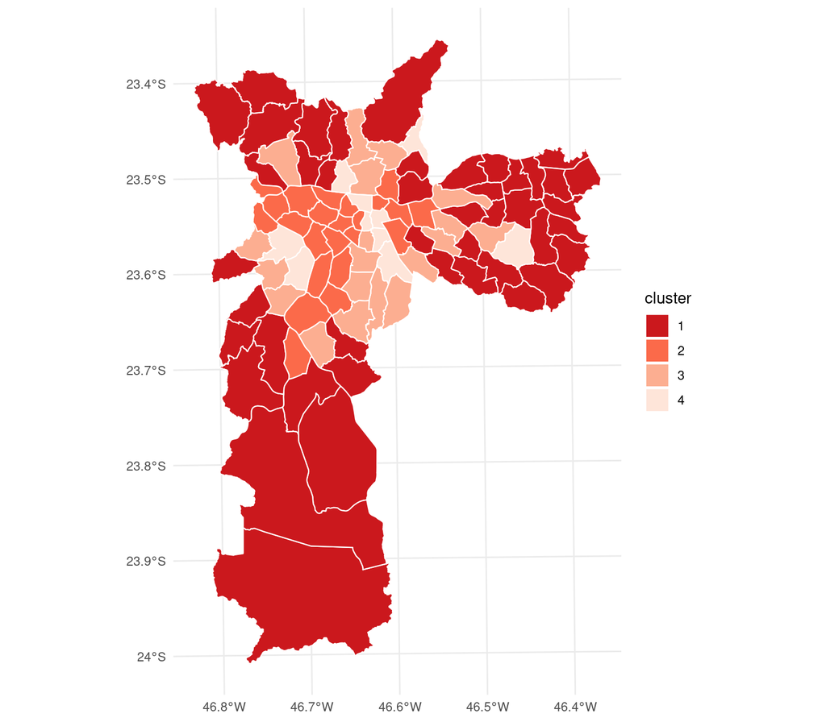

```r
df %>%
  ggplot(aes(fill = cluster)) +
  geom_sf(lwd=0.4, color="white") +
  scale_fill_brewer(palette = "Reds", direction = -1) +
  theme_minimal()
```